# Unicare zero inflated admissions counts models summary

Published

October 25, 2025

## Models

Based on earlier model results we consider Bayes and frequentist zero inflated Poisson and negative binomials models.

For the zero inflated Poisson model we use the following model specification:

$$\begin{aligned}
\textrm{counts}_i & \sim ZIP(\pi_i, \mu_i) \\
\log \mu_i & = \beta_0 + \beta_1 \textrm{cohort}_i + \beta_2 \textrm{chf}_i + \beta_3 \textrm{age}_i + \beta_4 \textrm{afib}_i\\
\log \frac{\pi_i}{1 - \pi_i} & = \gamma_0 + \gamma_1 \textrm{age}_i \\
\end{aligned}$$
Note that the zero inflated negative binomial models model the mean the same way. The expected value for these models, which is the average inpatient count, is

$$(1 - \pi_i) \mu_i$$

We scale the age variable as

$$age \rightarrow \frac{\textrm{age} - 60}{10}$$

for interpretability and for numerical stability.

### Effects sizes

Presently we are not modeling the $\pi$ using cohort. So we can compare cohorts with the same values of other predictors-whatever they are- simply using the ratios of the means $\mu_i$.

We cannot do across the board comparison of the effect on the probability of zero admissions as it varies depending on the values of the other covariates as well as the zero inflation probability $\pi$. But we can compare for given values of the covariates.

We do these comparisons below.

### Summary statistics; admissions

We consider admissions occurring within 270 day window of observation.

| cohort | count |
| --- | --- |
| control | 1051 |
| ibis | 117 |

#### Mean inpatient counts

Overall

| mean_count |
| --- |
| 0.512 |

By cohort

| cohort | mean_count |
| --- | --- |
| control | 0.549 |
| ibis | 0.179 |

So this is more than 50% reduction.

#### Proportion of zero admissions

Overall

[output not shown]

By cohort

| cohort | prop_zero_admit |
| --- | --- |
| control | 0.724 |
| ibis | 0.855 |

#### Mean admissions count for patients with one or more admissions

Overall

| mean_at_least_one_admit |
| --- |
| 0.263 |

By cohort

| cohort | mean_at_least_one_admit |
| --- | --- |
| control | 0.276 |
| ibis | 0.145 |

## Model results

**Frequentist zero inflated Poisson model**

This is the model specification above.

```
Call:
pscl::zeroinfl(formula = inpatient_count ~ cohort + age + chf + atrial_fibrillation |
    age, data = patients_events, dist = "poisson")

Pearson residuals:
   Min     1Q Median     3Q    Max
-0.784 -0.536 -0.454  0.145 13.527

Count model coefficients (poisson with log link):
                    Estimate Std. Error z value Pr(>|z|)
(Intercept)           0.4436     0.0883    5.02  5.1e-07 ***
cohortibis           -1.1633     0.2502   -4.65  3.3e-06 ***
age                  -0.1446     0.0466   -3.10   0.0019 **
chf                   0.1838     0.1211    1.52   0.1292
atrial_fibrillation   0.3695     0.1077    3.43   0.0006 ***

Zero-inflation model coefficients (binomial with logit link):
            Estimate Std. Error z value Pr(>|z|)
(Intercept)   1.0962     0.1275    8.60  < 2e-16 ***
age          -0.4649     0.0801   -5.81  6.4e-09 ***
---
Signif. codes:  0 '***' 0.001 '**' 0.01 '*' 0.05 '.' 0.1 ' ' 1

Number of iterations in BFGS optimization: 15
Log-likelihood: -1.09e+03 on 7 Df
```

**Frequentist zero inflated negative binomial model**

Described in the zero inflated models document. The same model spec as zero inflated Poisson, but with additional dispersion parameter $\theta$ which is estimated from the data (and not modeled) and increases the variance of the count portion of the model by $\mu^2/\theta$.

```
Call:
pscl::zeroinfl(formula = inpatient_count ~ cohort + age + chf + atrial_fibrillation |
    age, data = patients_events, dist = "negbin")

Pearson residuals:
    Min      1Q  Median      3Q     Max
-0.6483 -0.4842 -0.4244  0.0664 13.0365

Count model coefficients (negbin with log link):
                    Estimate Std. Error z value Pr(>|z|)
(Intercept)          -0.2363     0.1944   -1.22    0.224
cohortibis           -1.1461     0.2684   -4.27  2.0e-05 ***
age                  -0.1355     0.0679   -2.00    0.046 *
chf                   0.3708     0.1828    2.03    0.042 *
atrial_fibrillation   0.6521     0.1473    4.43  9.5e-06 ***
Log(theta)           -0.2262     0.2749   -0.82    0.411

Zero-inflation model coefficients (binomial with logit link):
            Estimate Std. Error z value Pr(>|z|)
(Intercept)   0.0696     0.3587    0.19     0.85
age          -0.6551     0.1431   -4.58  4.7e-06 ***
---
Signif. codes:  0 '***' 0.001 '**' 0.01 '*' 0.05 '.' 0.1 ' ' 1

Theta = 0.798
Number of iterations in BFGS optimization: 23
Log-likelihood: -1.05e+03 on 8 Df
```

It looks like the dispersion parameter is not significant. But the null is in fact that $\log \theta = 0$; that is, $\theta = 1$. To test whether the dispersion is significant we can perform a likelihood ratio test using $\chi^2$ distribution and obtain

```
'log Lik.' 5.03e-18 (df=8)
```

So the dispersion is in fact significant.

**Bayesian zero inflated Poisson model**

```
                    Estimate Est.Error    Q2.5   Q97.5
Intercept              0.442    0.0866  0.2682  0.6075
zi_Intercept           1.079    0.1214  0.8428  1.3184
cohortibis            -0.929    0.2184 -1.3673 -0.5032
age                   -0.126    0.0459 -0.2144 -0.0344
chf                    0.170    0.1196 -0.0692  0.4004
atrial_fibrillation    0.335    0.1056  0.1276  0.5416
zi_age                -0.398    0.0721 -0.5408 -0.2590
```

## Model fit and predictions

We can see that these models are in agreement, and the results do fit the data well.

#### Expected number of inpatient admissions; probabilities of zero admissions

If we take the mean of the `cohortibis` count coefficients for the two models as an estimate, the models suggest a mean admission count for ibis cohort is 0.35 times that of the control, assuming the same values for other predictors, which amounts to a 65 percent reduction.

#### Zero admissions probabilities

We can compare prevalences for outcomes in the data vs those predicted by the model. This was done in the `zer0_infl_admissions_models_2025-05_short.html`. We give a graphical illustration below with the Bayes model. Presently, we will compare what the models give as probabilities of admissions count outcomes for a single patient with the same age and conditions covariates, with one being `ibis` cohort and the other `control`.

For 60 year old patient, without no `chf` or `afib`, for ibis vs control, On the other hand, for the probability of zero admissions, the zero inflated Poisson model gives,

```
   cohort age chf atrial_fibrillation     0      1      2       3       4
1 control   0   0                   0 0.802 0.0821 0.0640 0.03325 0.01295
2    ibis   0   0                   0 0.903 0.0749 0.0182 0.00296 0.00036
         5
1 4.04e-03
2 3.51e-05
```

```
   cohort age chf atrial_fibrillation     0     1      2       3        4
1 control   1   1                   0 0.721 0.111 0.0902 0.04871 0.019735
2    ibis   1   1                   0 0.862 0.106 0.0268 0.00453 0.000573
        5
1 6.4e-03
2 5.8e-05
```

In either case we more than a 10% increase. This agrees with the difference in proportion of zero admits for ibis vs control above.

### Post predictive checks

We use Bayes model here. The coefficients are similar, but we can get a more complete picture of both the distributions of the coefficients, and the how well the model reproduces the observations, as well as model variability.

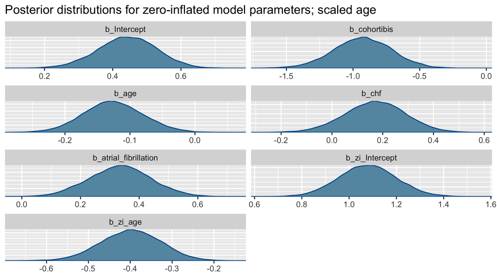

### Credible intervals

These are 50% and 90% “credible intervals”.

**Remark** These are the middle quantiles in the distribution for the various coefficients. We can interpret this as a probability the coefficient lies within the interval, according to the model. By contrast, a frequentist confidence interval does not admit a probabilistic interpretation this way. In particular, we can say that the probability the true parameter is less than the upper bound of a 90% credible interval is 95%, because of the area in the left tail. In that sense, a 90% credible interval is comparable to the upper limit of a 95% frequentist confidence interval, if, as in this case, we are concerned with that upper limit being greater than zero or not.

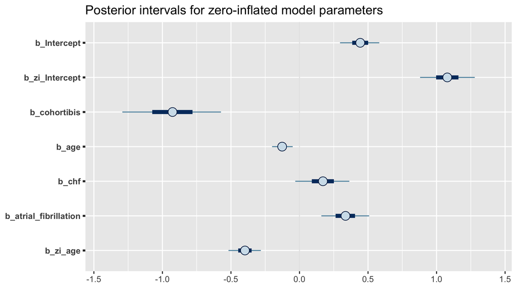

If anything, the model may inflate the zeros too much.

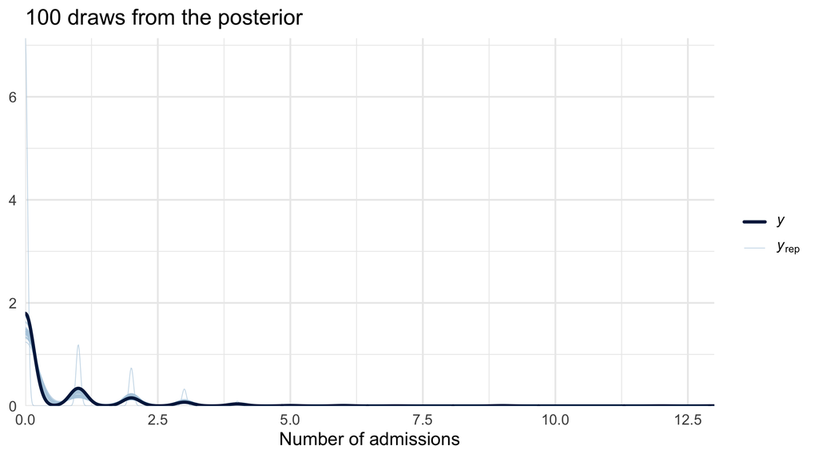

We plot posterior draws by cohort. Not surprisingly there is more uncertainty with the Ibis cohort, which has much smaller sample size.

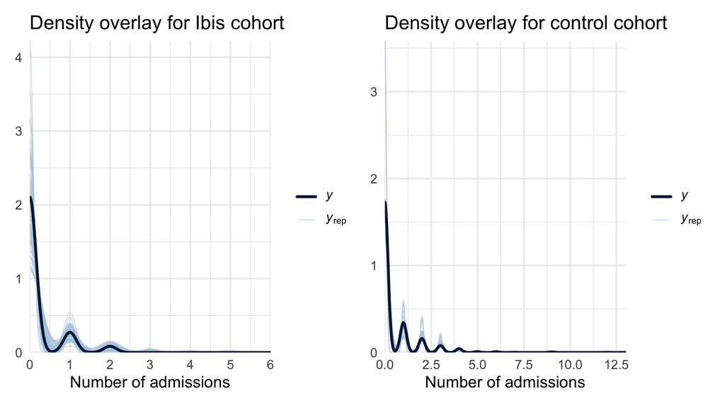

We can plot proportions of various counts in the posterior and compare with actual proportions in the data.

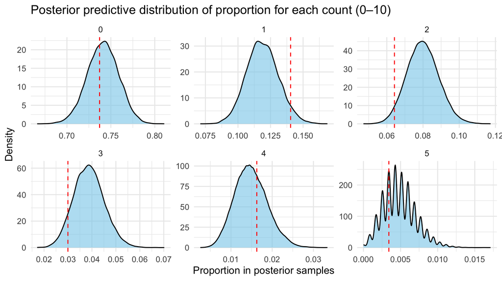

And also do this by cohort. There is not enough data

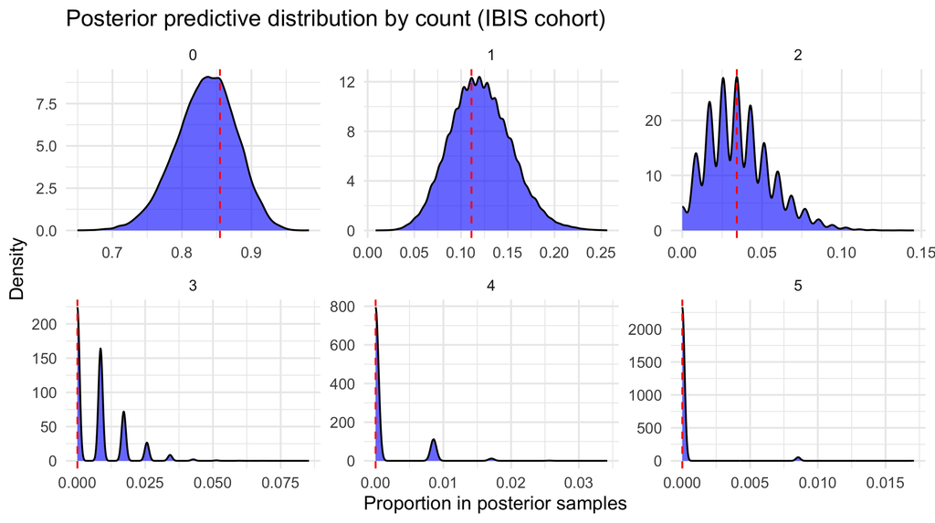

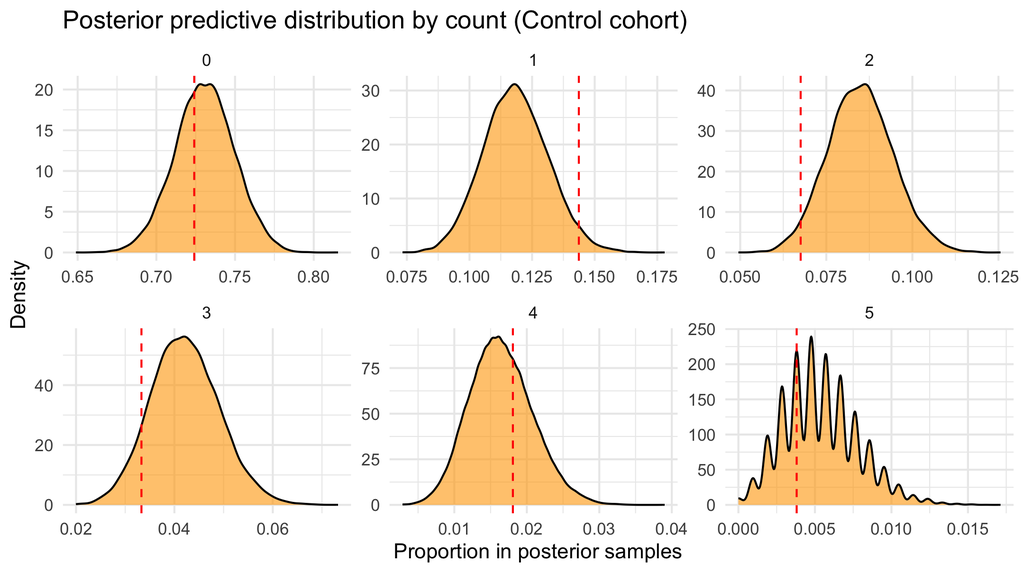